# Laringe

```r
require(survival)
require(MASS)
```

```r
laringe <- read.csv("laringe.csv", header = T, sep =",")
attach(laringe)
head(laringe)
```

|  | id | tpo | cens | edad | est |
| --- | --- | --- | --- | --- | --- |
| 1 | 1 | 0.6 | 1 | 77 | 1 |
| 2 | 2 | 1.3 | 1 | 53 | 1 |
| 3 | 3 | 2.4 | 1 | 45 | 1 |
| 4 | 4 | 3.2 | 1 | 58 | 1 |
| 5 | 5 | 3.3 | 1 | 76 | 1 |
| 6 | 6 | 3.5 | 1 | 43 | 1 |

```r
cox_lar1<-coxph(Surv(tpo,cens)~factor(est),data=laringe,x=T, method="breslow")
summary(cox_lar1)
```

```
Call:
coxph(formula = Surv(tpo, cens) ~ factor(est), data = laringe,
    x = T, method = "breslow")

  n= 90, number of events= 50

                coef exp(coef) se(coef)     z Pr(>|z|)
factor(est)2 0.06576   1.06797  0.45844 0.143   0.8859
factor(est)3 0.61206   1.84423  0.35520 1.723   0.0849 .
factor(est)4 1.72284   5.60040  0.41966 4.105 4.04e-05 ***
---
Signif. codes:  0 ‘***’ 0.001 ‘**’ 0.01 ‘*’ 0.05 ‘.’ 0.1 ‘ ’ 1

             exp(coef) exp(-coef) lower .95 upper .95
factor(est)2     1.068     0.9364    0.4348     2.623
factor(est)3     1.844     0.5422    0.9193     3.700
factor(est)4     5.600     0.1786    2.4604    12.748

Concordance= 0.668  (se = 0.037 )
Likelihood ratio test= 16.26  on 3 df,   p=0.001
Wald test            = 18.95  on 3 df,   p=3e-04
Score (logrank) test = 22.46  on 3 df,   p=5e-05
```

```r
cox_lar1$loglik
```

```
[1] -197.2129 -189.0812
```

```r
cox_lar2<-coxph(Surv(tpo,cens)~factor(est),data=laringe,x=T, method="breslow")
summary(cox_lar2)
```

```
Call:
coxph(formula = Surv(tpo, cens) ~ factor(est), data = laringe,
    x = T, method = "breslow")

  n= 90, number of events= 50

                coef exp(coef) se(coef)     z Pr(>|z|)
factor(est)2 0.06576   1.06797  0.45844 0.143   0.8859
factor(est)3 0.61206   1.84423  0.35520 1.723   0.0849 .
factor(est)4 1.72284   5.60040  0.41966 4.105 4.04e-05 ***
---
Signif. codes:  0 ‘***’ 0.001 ‘**’ 0.01 ‘*’ 0.05 ‘.’ 0.1 ‘ ’ 1

             exp(coef) exp(-coef) lower .95 upper .95
factor(est)2     1.068     0.9364    0.4348     2.623
factor(est)3     1.844     0.5422    0.9193     3.700
factor(est)4     5.600     0.1786    2.4604    12.748

Concordance= 0.668  (se = 0.037 )
Likelihood ratio test= 16.26  on 3 df,   p=0.001
Wald test            = 18.95  on 3 df,   p=3e-04
Score (logrank) test = 22.46  on 3 df,   p=5e-05
```

```r
cox_lar2$loglik
```

```
[1] -197.2129 -189.0812
```

Al modelo de Cox anterior se le adiciona la variable edad, es denominado cox lar3.

```r
cox_lar3<-coxph(Surv(tpo,cens)~factor(est)+edad,data=laringe, x=T,method="breslow")
summary(cox_lar3)
```

```
Call:
coxph(formula = Surv(tpo, cens) ~ factor(est) + edad, data = laringe,
    x = T, method = "breslow")

  n= 90, number of events= 50

                coef exp(coef) se(coef)     z Pr(>|z|)
factor(est)2 0.13856   1.14862  0.46231 0.300    0.764
factor(est)3 0.63835   1.89335  0.35608 1.793    0.073 .
factor(est)4 1.69306   5.43607  0.42221 4.010 6.07e-05 ***
edad         0.01890   1.01908  0.01425 1.326    0.185
---
Signif. codes:  0 ‘***’ 0.001 ‘**’ 0.01 ‘*’ 0.05 ‘.’ 0.1 ‘ ’ 1

             exp(coef) exp(-coef) lower .95 upper .95
factor(est)2     1.149     0.8706    0.4642     2.842
factor(est)3     1.893     0.5282    0.9422     3.805
factor(est)4     5.436     0.1840    2.3763    12.436
edad             1.019     0.9813    0.9910     1.048

Concordance= 0.682  (se = 0.039 )
Likelihood ratio test= 18.07  on 4 df,   p=0.001
Wald test            = 20.82  on 4 df,   p=3e-04
Score (logrank) test = 24.33  on 4 df,   p=7e-05
```

```r
cox_lar3$loglik
```

```
[1] -197.2129 -188.1794
```

Finalmente, el modelo de Cox que incluye estadio, edad y la interaccion estadio y edad es nominado como cox lar4,

```r
cox_lar4<-coxph(Surv(tpo,cens)~factor(est)+edad+
+factor(est)*edad,data=laringe,x=T,method="breslow")
summary(cox_lar4)
```

```
Call:
coxph(formula = Surv(tpo, cens) ~ factor(est) + edad + +factor(est) *
    edad, data = laringe, x = T, method = "breslow")

  n= 90, number of events= 50

                       coef exp(coef)  se(coef)      z Pr(>|z|)
factor(est)2      -7.946142  0.000354  3.678209 -2.160   0.0307 *
factor(est)3      -0.122500  0.884706  2.468331 -0.050   0.9604
factor(est)4       0.846986  2.332605  2.425717  0.349   0.7270
edad              -0.002559  0.997444  0.026051 -0.098   0.9218
factor(est)2:edad  0.120254  1.127783  0.052307  2.299   0.0215 *
factor(est)3:edad  0.011351  1.011416  0.037449  0.303   0.7618
factor(est)4:edad  0.013673  1.013767  0.035967  0.380   0.7038
---
Signif. codes:  0 ‘***’ 0.001 ‘**’ 0.01 ‘*’ 0.05 ‘.’ 0.1 ‘ ’ 1

                  exp(coef) exp(-coef) lower .95 upper .95
factor(est)2       0.000354  2824.6562 2.619e-07    0.4786
factor(est)3       0.884705     1.1303 7.011e-03  111.6467
factor(est)4       2.332605     0.4287 2.009e-02  270.7790
edad               0.997444     1.0026 9.478e-01    1.0497
factor(est)2:edad  1.127783     0.8867 1.018e+00    1.2495
factor(est)3:edad  1.011416     0.9887 9.398e-01    1.0884
factor(est)4:edad  1.013767     0.9864 9.448e-01    1.0878

Concordance= 0.694  (se = 0.039 )
Likelihood ratio test= 24.27  on 7 df,   p=0.001
Wald test            = 24.11  on 7 df,   p=0.001
Score (logrank) test = 28.59  on 7 df,   p=2e-04
```

```r
cox_lar4$loglik
```

```
[1] -197.2129 -185.0775
```

Se hace el analisis de residuales para los modelos de Cox con y sin interaccion y desde este analisis se debe decidir sobre cual de los dos modelos se ajusta mas adecuadamente a los datos. Los residuos escalados de Schoenfeld para el modelo de Cox con interacci on se obtienen mediante el codigo R como se muestra a continuacion.

```r
residuals(cox_lar4,type="scaledsch")
```

```
    factor(est)2 factor(est)3 factor(est)4          edad
0.1    -3.124213  -0.05903965  11.39950689 -0.0010994382
0.2  -100.943089   0.38643831   0.70993999  0.0014972097
0.3    -6.747996  41.15641021   0.85077726  0.0108842882
0.3    -5.620362 -10.94194493   0.81807956  0.0148383058
0.3    -8.615577  -0.06762869  -0.79467586 -0.0013755510
0.4    -8.639741   0.17720957 -11.28303587 -0.0014625254
0.5    -6.351577  22.50294465   0.28193913  0.0127509938
0.6    16.958197  22.93602451  22.58317927  0.4098155323
0.7    -5.049589 -29.19891211   0.37966611  0.0194687171
0.8    -4.855969 -36.70327450   0.36877782  0.0203109637
0.8    -8.368348   0.26138583  11.28487416  0.0026853612
0.8    -8.469430   0.17219172 -15.82554882  0.0014606245
1      -6.541510  40.90341553   0.04678575  0.0151440606
1      -8.175823  -0.11479080  60.96384721  0.0057105370
1.3   -36.699422 -30.29387816 -28.69752429 -0.4004000255
1.3    -5.968131  15.35496281   2.00292039  0.0176096970
1.5    -8.578945   0.17194546   6.40971186  0.0007514074
1.6    -5.996000   5.86782480   2.04166711  0.0155822640
1.8    53.901874   0.42387862   1.97825819  0.0140677218
1.8    -5.453946 -17.72264834   2.04487282  0.0176539113
1.9    -6.080595  31.71372556   2.10378636  0.0143308332
1.9    -5.106729 -13.28030843   2.07554744  0.0177456666
2      61.719396   0.35170021   2.04728769  0.0155684717
2      -8.061958   0.21193241   4.67438044  0.0021332181
2.3    -7.370258   0.29154118  19.51317651  0.0034143311
2.4   -53.665357 -47.86660720 -44.98323759 -0.6723367674
3.2   -24.686142 -19.94870488 -17.34732635 -0.2412917764
3.2    -5.485215  28.88070233   2.31778089  0.0059802214
3.3    15.185748  19.66099905  21.83166288  0.3612522561
3.5   -58.383014 -53.00498951 -50.91127061 -0.7552636398
3.5   -20.225399 -15.50953085 -13.36080364 -0.1784218283
3.5    -4.129689 -35.03024447   1.84647261  0.0058390849
3.6    10.406502  -2.01210050   0.95484231 -0.0134936166
3.6    -8.345688  -2.26638762  -0.57448252 -0.0239195299
3.8    -7.921479  -1.88418736 -27.79727032 -0.0277779953
4     -38.362117 -34.67016021 -35.14695529 -0.4670576763
4     -13.671896 -10.40839284 -10.84959431 -0.0938070924
4     -69.278592  -1.57788272  -2.36009392 -0.0239520706
4.3    30.876528  39.33605182  38.73369822  0.6740508941
```

[output cut: 47 more lines]

```
4          0.53698513      0.4902506194       0.524731397
4          0.15870949      0.1189770443       0.150444497
4          1.08406526      0.0352941140       0.082332085
4.3       -0.52310635     -0.6439141226      -0.612947448
5          0.19770791     -0.1767130868       0.045220394
5.3       -0.34814112     -0.5068662397      -0.482736535
6         -0.12496785     -0.2953720164      -0.266168943
6.2        0.47750764      0.0047122570       0.049592416
6.3        0.22509675      0.1864538492       0.046977204
6.4       -0.16401558     -0.3703049860      -0.346003280
6.4        0.23787429      0.0189034160       0.050541597
6.5        0.17708879     -0.0498567303      -0.019193450
7         -0.69392195     -0.0186395751       0.024192279
7.4        0.12694871     -0.1124921302      -0.068818632
7.8        0.14700400      0.0471886018      -0.006114651
```

```r
cox.zph(cox_lar4,transform="identity") ## g(t)=t
```

```
                 chisq df    p
factor(est)       4.75  3 0.19
edad              1.34  1 0.25
factor(est):edad  4.48  3 0.21
GLOBAL            6.73  7 0.46
```

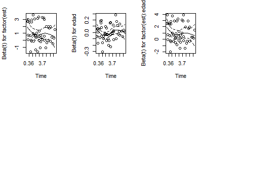

```r
par(mfrow=c(2,4))
plot(cox.zph(cox_lar4))
```

```r
H<-basehaz(cox_lar4,centered=F)
```

```
the model contains interactions; the default curve based on columm means of the X matrix is almost certainly not useful. Consider adding a newdata argument.
```

```r
tpos<-H$time
H0<-H$hazard
S0<-exp(-H0)
round(cbind(tpos,S0,H0),digits=5)
```

```
      tpos      S0      H0
 [1,]  0.1 0.99377 0.00625
 [2,]  0.2 0.98739 0.01269
 [3,]  0.3 0.96737 0.03318
 [4,]  0.4 0.96039 0.04041
 [5,]  0.5 0.95319 0.04794
 [6,]  0.6 0.94596 0.05555
 [7,]  0.7 0.93875 0.06321
 [8,]  0.8 0.91713 0.08650
 [9,]  1.0 0.90154 0.10365
[10,]  1.3 0.88552 0.12158
[11,]  1.5 0.87745 0.13073
[12,]  1.6 0.86907 0.14033
[13,]  1.8 0.85231 0.15980
[14,]  1.9 0.83549 0.17974
```

[output cut: 40 more lines]

```r
par(mfrow=c(1,2))
# GRAFICAS DE SOBREVIDA 50 A~NOS
plot(tpos,S0^(exp(-0.002559*50)),ylim=c(0,1),type="l",xlab="Tiempo",ylab="S(t|x)")
lines(tpos,S0^(exp(-7.946142+(-0.002559+0.120254)*50)), lty=2)
```

```r
lines(tpos,S0^(exp(-0.122500+(-0.002559+0.011351)*50)), lty=3)
lines(tpos,S0^(exp(0.846986+(-0.002559+0.013673)*50)), lty=4)
```

```r
# GRAFICAS DE SOBREVIDA 65 A~NOS
plot(tpos,S0^(exp(-0.002559*65)),ylim=c(0,1),type="l",xlab="Tiempo",ylab="S(t|x)")
lines(tpos,S0^(exp(-7.946142+(-0.002559+0.120254)*65)), lty=2)
```

[figure not shown]

```r
lines(tpos,S0^(exp(-0.122500+(-0.002559+0.011351)*65)), lty=3)
lines(tpos,S0^(exp(0.846986+(-0.002559+0.013673)*65)), lty=4)
```

```r
S0^(exp(-7.946142+(-0.002559+0.120254)*65))
```

```
 [1] 0.9953630 0.9906049 0.9756229 0.9703889 0.9649708 0.9595233
 [7] 0.9540725 0.9376849 0.9257995 0.9135382 0.9073372 0.9008859
[13] 0.8879288 0.8748603 0.8615800 0.8615800 0.8544994 0.8470971
[19] 0.8470971 0.8470971 0.8470971 0.8309887 0.8227137 0.7977792
[25] 0.7807506 0.7807506 0.7710317 0.7395034 0.7278506 0.7278506
[31] 0.7278506 0.7125602 0.7125602 0.6949519 0.6949519 0.6949519
[37] 0.6755938 0.6755938 0.6555385 0.6334376 0.5881430 0.5638902
[43] 0.5638902 0.5338386 0.5023002 0.5023002 0.5023002 0.4670951
[49] 0.4670951 0.4670951 0.4670951 0.4670951 0.4670951 0.4670951
```